# Aside

## Disclaimer

Last updated on 2026-09-15.

## Contact

- maximilian.larter@gmail.com
- [twitter](https://x.com/maxlarter) / [Bluesky](https://bsky.app/profile/maxlarter.bsky.social)
- maxlarter.github.io
- +33 679709275
- 10 rue HG Wells,  
  33600 Pessac, France
- August 5th, 1987. Derby (UK)

## Skills

- Native speaker in **English** and **French**
- data analysis, stats, modelling, GIS (R, python, git, SAS)
- Plant hydraulics, physiology, gas exchange
- Molecular biology, phylogenetics

## Citations

965 citations, h-index 13

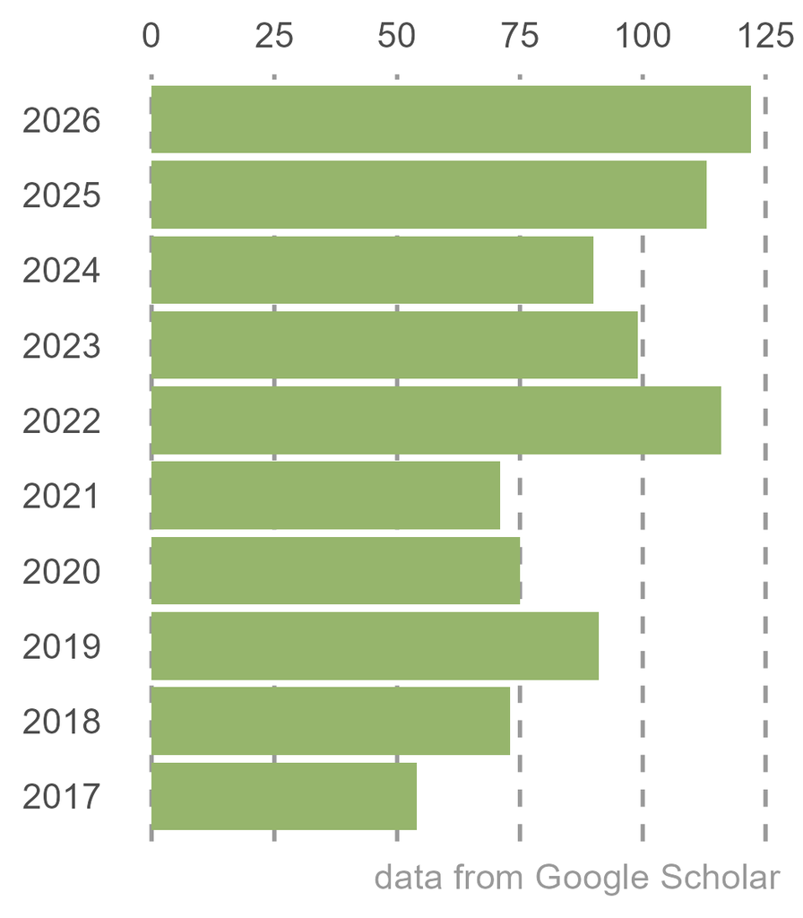

#### [full publication list](https://maxlarter.github.io/publications/publications.html)

# Main

## Maximilian Larter

### I am a plant ecophysiologist and an evolutionary biologist. My primary research interest is understanding how plants respond and adapt to their environment, especially under climate change. I study functional traits and key physiological processes, and use statistics and models to predict the impacts of climate change on the performance, survival, and future distributions of wild and cultivated species.

## Research Experience

### Postdoc - modelling urban heat islands and carbon storage

[Sylvain Delzon’s lab](http://sylvain-delzon.com/)

INRAE, Bordeaux, France

2025

- Model the impacts of management, development and land use changes on local temperature and carbon storage on the university campus.

### Postdoc - Plant hydraulics & trait trade-offs, forest ecology and biogeography

[Sylvain Delzon’s lab](http://sylvain-delzon.com/)

INRAE, Bordeaux, France

2024 - 2021

### Postdoc - Herb hydraulics, positive root pressure and drought resistance in Brassicaceae

[Frederic Lens’s lab](https://www.naturalis.nl/en/science/functional-traits)

Naturalis, Leiden, The Netherlands

2021 - 2019

### Postdoc - Evolution of the anthocyanin pathway in Iochrominae

[Stacey Smith’s lab](https://www.colorado.edu/smithlab/)

University of Colorado, Boulder, USA

2019 - 2017

### PhD - Evolution of cavitation resistance in conifers

[Sylvain Delzon’s lab](http://sylvain-delzon.com/)

Université de Bordeaux, France

2016 - 2012

- *Supervisors*: Sylvain Delzon and Jean-Christophe Domec

## Education

### Qualification CNU

Sections 66 Physiologie & 67 Biol. des populations et écologie

N/A

2025 - 2022

### PhD in evolutionary, functional and community ecology. *Thesis*: Evolution of cavitation resistance in conifers

Université de Bordeaux

Bordeaux, France

2016 - 2012

- *Supervisors*: Sylvain Delzon and Jean-Christophe Domec

### MSc - Terrestrial Ecosystem Functioning and Modelling

Université de Bordeaux

Bordeaux, France

2011

### BSc - Organismal Biology

Université d’Orléans

Orléans, France

2008

## Selected Publications

### **M Larter**, G Charrier, S Delzon, W Hammond, A Baranger, C Bertrand, N Martin-StPaul, G Kunstler (2025) Weak global trade-off between frost and drought resistance in trees, *New Phytologist.* pdf

N/A

N/A

2025

### A Baranger, T Cordonnier, G Charrier, S Delzon, **M Larter**, N Martin-StPaul, G Kunstler (2024) Living on the edge - physiological tolerance to frost and drought explains range limits of 35 European tree species, *Ecography.* pdf

N/A

N/A

2024

### **M Larter**, A Dunbar-Wallis, AE Berardi, SD Smith (2019) Developmental control of convergent floral pigmentation across evolutionary timescales, *Developmental dynamics*, 248 (11), 1091-1100. pdf

N/A

N/A

2019

### **M Larter**, A Dunbar-Wallis, AE Berardi, SD Smith (2018) Convergent evolution at the pathway level: predictable regulatory changes during flower color transitions, *Molecular biology and evolution*, 35 (9), 2159-2169. pdf

N/A

N/A

2018

### **M Larter**, S Pfautsch, JC Domec, S Trueba, N Nagalingum, S Delzon (2017) Aridity drove the evolution of extreme embolism resistance and the radiation of conifer genus Callitris, *New Phytologist.*, 215 (1), 97-112. pdf

N/A

N/A

2017

### **M Larter**, TJ Brodribb, S Pfautsch, R Burlett, H Cochard, S Delzon (2015) Extreme aridity pushes trees to their physical limits, *Plant Physiology*, 168 (3), 804-807. pdf

N/A

N/A

2015

### PS Bouche, **M Larter**, JC Domec, R Burlett, P Gasson, S Jansen, S Delzon (2014) A broad survey of hydraulic and mechanical safety in the xylem of conifers, *Journal of Experimental Botany*, 65 (15), 4419-4431. pdf

N/A

N/A

2014

## Grants and funding

### Active participation in grant writing

ANR projects, Calls for Recherche Inter-disciplinaire et Exploratoire and Prématuration-Innovation at Université de Bordeaux, Fondation pour la Recherche et la Biodiversité IDEASHARE & DATASHARE

N/A

N/A

### Alberta Mennega Stichting fieldwork grant

1,250€

Leiden (The Netherlands)

2020

### External mobility grant from the COTE Cluster of Excellence

3,000€

Bordeaux (France)

2014

### Research Exchange Program (Inbound)

AU$3350

Western Sydney University, NSW (Australia)

## Conferences and Presentations

### Poster - “Weak global trade-off between frost and drought resistance in trees”

Xylem International Meeting XIM6

Sevilla (Spain)

2025

### Talk - “Trade off in cold and drought tolerance in trees”

Xylem International Meeting XIM5

Wurzburg (Germany)

2022

### Talk - “Linking changes in gene expression to the macroevolution of flower color in Iochrominae”

Evolution Meeting

Portland, Oregon

2017

### Talk - “The evolution of cavitation resistance in conifers and the case of world-record *Callitris*”

Xylem International Meeting XIM2

Bordeaux (France)

2015

## Professional service

### Guest Lectures (1h)

MSc courses Plant Physiology, Methods in Biodiversity Analysis

Bordeaux U. & Leiden U.

N/A

### Supervision of several 6 month student projects

1 BSc and 4 MSc - two leading to publications

Bordeaux U. & Leiden U.

### Regular reviewer for scientific journals

New Phytologist, Tree Physiology, PCE, Evolution, American Journal of Botany, Plos One, BMC Evol. Biol.

N/A

### Postdoc and short term contract representative 2021-2022

Conseil d’Unité UMR Biogeco

Bordeaux (France)